# Evaluación estadística

Ivonne Yáñez Mendoza

##### Profesor: Conrado M. Manuel García

##### Master big data & business analytics, Universidad Complutense de Madrid

##### 31 de mayo de 2022

### **Resumen**

Este estudio estadístico ha sido realizado para observar las medidas de anchura de cráneo según el periodo histórico observado, los cuales son predinástico temprano y predinástico tardío.

La finalidad de este estudio es poder responder en forma estadística a la pregunta planteada en el enunciado de este ejercicio de si existen diferencias en la longitud de anchura de los cráneos egipcios según el paso del tiempo.

### **Ejercicio 1**

Para resolver este ejercicio se han creado dos dataframes a partir del un archivo excel que contiene los datos tanto para el grupo predinástico temprano como el predinástico tardío.

Con estos datos por separado se han analizado cada uno de estos dos periodos históricos, generando las respectivas mediciones y gráficos pertinentes.

**Ejercicio 1.a**

**Enunciado:** Se deben obtener con R las diferentes medidas de centralización y dispersión, asimetría y curtosis además de obtener el gráfico de caja y bigotes para cada submuestra.

**Apartado periodo predinástico temprano**

Medidas de centralización, dispersión, asimetría y curtosis para el periodo predinástico temprano o época 1.

Anchura de cráneo del periodo predinástico temprano

| Epoca | N | Media | Mediana | Moda | Rango | Desviacion | Pearson | Fisher | Curtosis |
| --- | --- | --- | --- | --- | --- | --- | --- | --- | --- |
| 1 | 30 | 131.5 | 131.5 | 131 | 4 | 0.82 | 0.0062 | 0.624 | 1.0222 |
| 1 | 30 | 131.5 | 131.5 | 132 | 4 | 0.82 | 0.0062 | 0.624 | 1.0222 |

Cuartiles del periodo predinástico temprano

| Época | N | 0% | 25% | 50% | 75% | 100% |
| --- | --- | --- | --- | --- | --- | --- |
| 1 | 30 | 130 | 131 | 131.5 | 132 | 134 |

**Nota**: En la moda se ha encontrado un empate entre el valor 131 y 132. El resto de mediciones como se puede observar, se mantiene intacto.

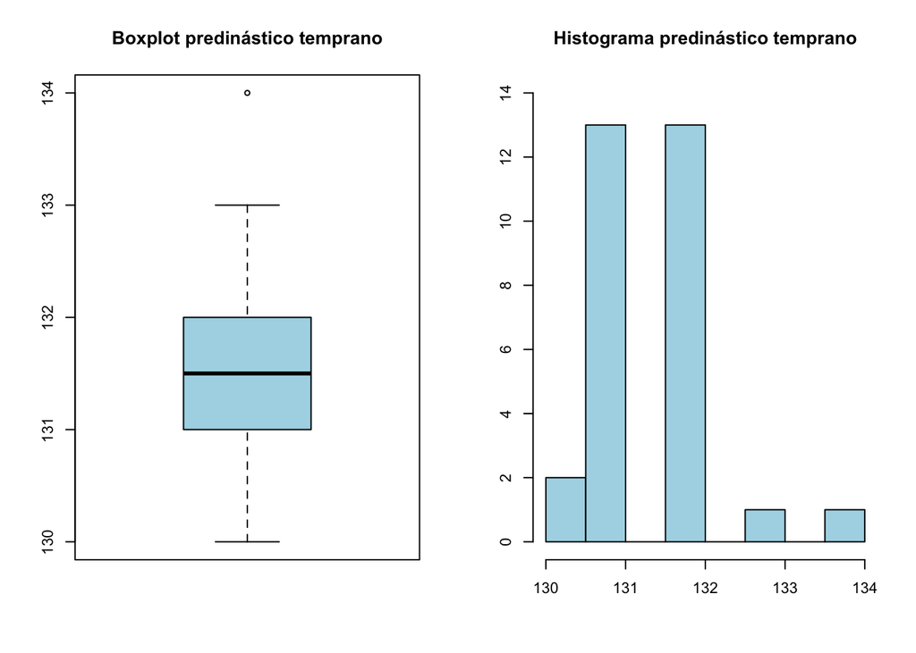

**Apartado periodo predinástico tardío**

Medidas de centralización, dispersión, asimetría y curtosis para el periodo predinástico tardío o grupo 2.

Anchura de cráneo del periodo predinástico tardío

| Epoca | N | Media | Mediana | Moda | Rango | Desviacion | Pearson | Fisher | Curtosis |
| --- | --- | --- | --- | --- | --- | --- | --- | --- | --- |
| 2 | 30 | 132.5 | 133 | 133 | 4 | 1.01 | 0.0076 | 0.185 | -0.3707 |

Cuartiles del periodo predinástico tardío

| N | Casos | 0% | 25% | 50% | 75% | 100% |
| --- | --- | --- | --- | --- | --- | --- |
| 2 | 30 | 131 | 132 | 133 | 133 | 135 |

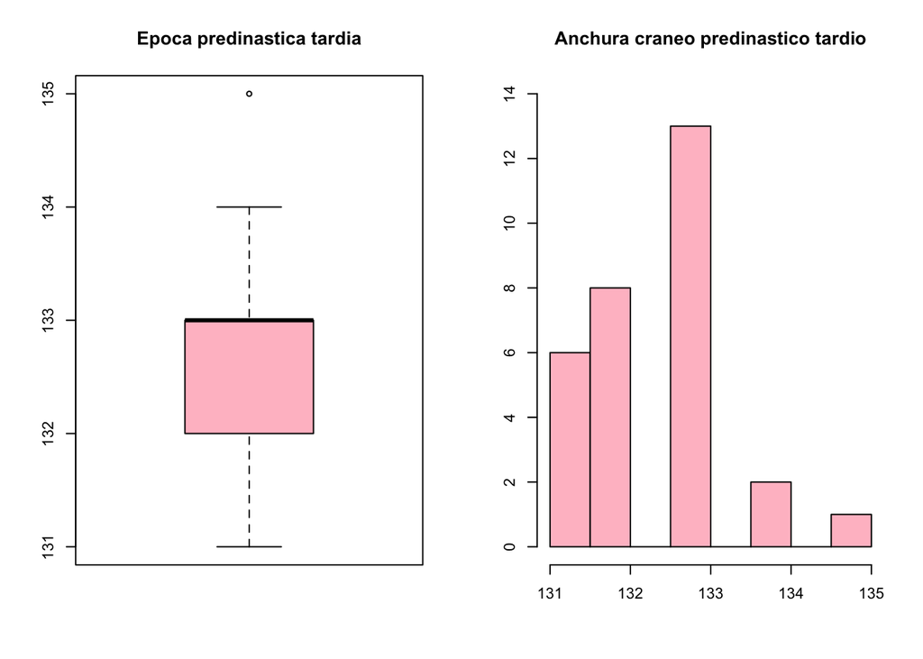

**Ejercicio 1.b**  
**Estudio preliminar de la normalidad**  
**Enunciado:** Determinar si cada una de las dos submuestras sigue una distribución normal utilizando el test de Kolmogorov-Smirnov.

En primer lugar se han creado dos gráficos, uno de tipo histograma y el otro de tipo *Quantile-Quantile plot* o qqplot para observar si se evidencia distribución normal, o no, de los datos procesados.

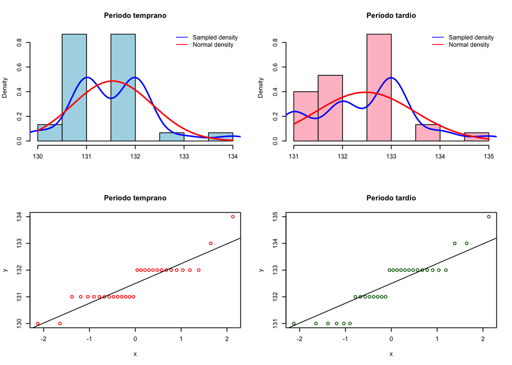

Los gráficos contrastados indican que las muestras **no** seguirían una distribución normal y para comprobar esto se contrastan los datos con una prueba estadística que asegure fiabilidad.

**Pruebas para comprobar si los datos siguen una distribución normal**

En un principio se ha aplicado la prueba de **Kolmogorov-Smirnov** para distribución normal tal y como lo indica el enunciado de este ejercicio, arrojando los siguientes resultados:

1. Periodo predinástico temprano:

```
    One-sample Kolmogorov-Smirnov test

data:  pre_temprano$Anchura.del.cráneo
D = 0.24246, p-value = 0.05877
alternative hypothesis: two-sided
```

Siendo **P-value(0.05877) >** $\alpha$ (0.05): No hay evidencia suficiente para rechazar la hipótesis nula. Por lo tanto, no se puede rechazar que la muestra siga una distribución normal.

2. Periodo predinástico tardío:

```
    One-sample Kolmogorov-Smirnov test

data:  pre_tardio$Anchura.del.cráneo
D = 0.23496, p-value = 0.07285
alternative hypothesis: two-sided
```

Siendo **P-value(0.07285) >** $\alpha$ (0.05): No hay evidencia suficiente para rechazar la hipótesis nula. Por lo tanto, no se puede rechazar que la muestra siga una distribución normal.

El problema con esta prueba es la cantidad relativamente pequeña de datos además de una alerta en R que habla de empate en la muestra.

Conociendo entonces los problemas asociados a la prueba de Kolmogorov-Smirnov para este ejercicio en particular y entendiendo que las muestras de este estudio son de 30 casos por submuestra se ha decidido utilizar el test de **Shapiro-Wilk** para normalidad, obteniendo los siguientes resultados:

1. Periodo predinástico temprano

```
    Shapiro-Wilk normality test

data:  pre_temprano$Anchura.del.cráneo
W = 0.83781, p-value = 0.0003481
```

Siendo **P-value(0.0003481) <** $\alpha$ (0.05): Existe evidencia suficiente para rechazar la hipótesis nula, por lo tanto la muestra para el periodo predinástico temprano **no sigue una distribución normal.**

2. Periodo predinástico tardío

```
    Shapiro-Wilk normality test

data:  pre_tardio$Anchura.del.cráneo
W = 0.8832, p-value = 0.003341
```

Otra alternativa es utilizar la **corrección de Lilliefors** para el test Kolmogorov Smirnov, al aplicarlo sobre las submuestras se obtienen los siguientes resultados.

1. Periodo predinástico temprano

```
    Lilliefors (Kolmogorov-Smirnov) normality test

data:  pre_temprano$Anchura.del.cráneo
D = 0.24246, p-value = 9.677e-05
```

Siendo **P-value(0.00009677) <** $\alpha$ (0.05): Existe evidencia suficiente para rechazar la hipótesis nula, por lo tanto la muestra para el periodo predinástico temprano **no sigue una distribución normal.**

2. Periodo predinástico tardío

```
    Lilliefors (Kolmogorov-Smirnov) normality test

data:  pre_tardio$Anchura.del.cráneo
D = 0.23496, p-value = 0.0001938
```

### **Ejercicio 2**

**Ejercicio 2.a Intervalos de confianza e interpretación de resultados**

Se necesita obtener un intervalo de confianza (0.9, 0.95 y 0.99) para la diferencia de medias de la anchura de la cabeza en ambos periodos históricos.

```
    Two Sample t-test

data:  pre_temprano$Anchura.del.cráneo and pre_tardio$Anchura.del.cráneo
t = -3.9354, df = 58, p-value = 0.0002248
alternative hypothesis: true difference in means is not equal to 0
90 percent confidence interval:
 -1.3297600 -0.5369067
sample estimates:
mean of x mean of y
 131.5333  132.4667
```

```
    Two Sample t-test

data:  pre_temprano$Anchura.del.cráneo and pre_tardio$Anchura.del.cráneo
t = -3.9354, df = 58, p-value = 0.0002248
alternative hypothesis: true difference in means is not equal to 0
95 percent confidence interval:
 -1.4080621 -0.4586046
sample estimates:
mean of x mean of y
 131.5333  132.4667
```

```
    Two Sample t-test

data:  pre_temprano$Anchura.del.cráneo and pre_tardio$Anchura.del.cráneo
t = -3.9354, df = 58, p-value = 0.0002248
alternative hypothesis: true difference in means is not equal to 0
99 percent confidence interval:
 -1.5649604 -0.3017063
sample estimates:
mean of x mean of y
 131.5333  132.4667
```

Se obtienen los intervalos de confianza con la función t.test especificando los intervalos requeridos.

En base a la información entregada con la aplicación de la función se concluye lo siguiente:

**Ejercicio 2.b**

**Aplicación del test-t para contrastar la igualdad de medias**

Siguiendo los apuntes vistos en la asignatura, para poder aplicar un t-test en muestras independientes se deben dar ciertas condiciones para la fiabilidad de la prueba.

Condiciones t-test:

1. **Independencia de los datos:** Para este análisis en particular se asume que ambas muestras son independientes.
2. **Normalidad:** Los datos deben seguir una distribución normal, pero en este caso y en base a las pruebas aplicadas con el test de Shapiro-Wilk, los datos tanto en el periodo temprano como en el tardío **no** siguen una distribución normal.
3. **Varianzas iguales:** La ultima condición a cumplir es que los grupos independientes deben tener varianzas iguales. Para ver si esta condición se cumple, en primer lugar, se crea un gráfico de caja y bigote para constatar de forma visual la igualdad. Observando el gráfico se deduce que las varianzas **podrían ser iguales**, pero al igual que en las pruebas anteriores además de gráficos, es preciso aplicar una prueba estadística para afirmar o rechazar tal afirmación, para esto se aplica el Levene Test siendo este test el mas adecuado al no tener las submuestras una distribución normal (vistas con el test de Shapiro-Wilk)

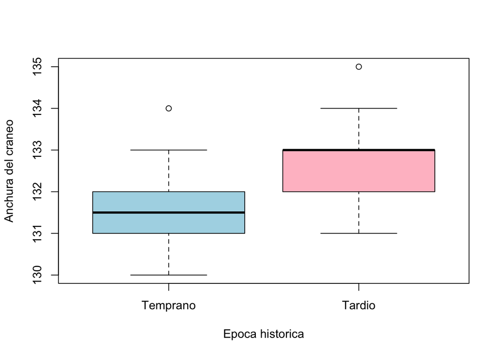

Aplicado el Levene test, se observan los siguientes resultados:

```
Levene's Test for Homogeneity of Variance (center = median)
      Df F value Pr(>F)
group  1  0.6195 0.4344
      58
```

Siendo **P-value(0.4344) >** $\alpha$ (0.05): No hay evidencia suficiente para rechazar la hipótesis nula. Por lo tanto, no se puede rechazar que las varianzas de ambas muestras son iguales. Es entonces que al no poder rechazar la hipótesis nula se asume que las varianzas son iguales para efectos del t-test.

*Notas sobre la aplicación de la prueba*

A pesar de que no se cumplen completamente las condiciones para aplicar el t-test en el enunciado de este ejercicio de evaluación se pide aplicar de todas formas el test y comentar conclusiones.

Siendo la condición de normalidad la que no se cumple (siguiendo los resultados de Shapiro-Wilk) una alternativa para comprobar si las media de las muestras son iguales, es utilizar una prueba de inferencia no paramétrica donde no se asume la normalidad, como es es el Test de Wilcoxon Mann Whitney.

Expuesto lo anterior se aplica el t-test:

```
    Two Sample t-test

data:  pre_temprano$Anchura.del.cráneo and pre_tardio$Anchura.del.cráneo
t = -3.9354, df = 58, p-value = 0.0002248
alternative hypothesis: true difference in means is not equal to 0
95 percent confidence interval:
 -1.4080621 -0.4586046
sample estimates:
mean of x mean of y
 131.5333  132.4667
```

Siendo **P-value(0.0002248) <** $\alpha$ (0.05): Existe evidencia suficiente para rechazar la hipótesis nula, por lo tanto las muestras evidencian diferencias entre la media del ancho de los cráneos, siendo en el periodo predinástico tardío donde se evidencia mayor anchura.